# 22085539_KhagendraMahaseth

1. Data Preparation

1.Write a python program to load data into pandas DataFrame

```python
# Importing necessary libraries for data manipulation and visualization for the following data set.
import pandas as pd
import numpy as np
import matplotlib.pyplot as mlp
```

```python
# Loading the dataset from 'ScienceSalaries.csv' into the data frame and display its contents and its data.
science_salaries = pd.read_csv('ScienceSalaries.csv')
science_salaries
```

|  | work_year | experience_level | employment_type | job_title | salary | salary_currency | salary_in_usd | employee_residence | remote_ratio | company_location | company_size |
| --- | --- | --- | --- | --- | --- | --- | --- | --- | --- | --- | --- |
| 0 | 2023 | SE | FT | Principal Data Scientist | 80000 | EUR | 85847 | ES | 100 | ES | L |
| 1 | 2023 | MI | CT | ML Engineer | 30000 | USD | 30000 | US | 100 | US | S |
| 2 | 2023 | MI | CT | ML Engineer | 25500 | USD | 25500 | US | 100 | US | S |
| 3 | 2023 | SE | FT | Data Scientist | 175000 | USD | 175000 | CA | 100 | CA | M |
| 4 | 2023 | SE | FT | Data Scientist | 120000 | USD | 120000 | CA | 100 | CA | M |
| ... | ... | ... | ... | ... | ... | ... | ... | ... | ... | ... | ... |
| 3750 | 2020 | SE | FT | Data Scientist | 412000 | USD | 412000 | US | 100 | US | L |
| 3751 | 2021 | MI | FT | Principal Data Scientist | 151000 | USD | 151000 | US | 100 | US | L |
| 3752 | 2020 | EN | FT | Data Scientist | 105000 | USD | 105000 | US | 100 | US | S |
| 3753 | 2020 | EN | CT | Business Data Analyst | 100000 | USD | 100000 | US | 100 | US | L |
| 3754 | 2021 | SE | FT | Data Science Manager | 7000000 | INR | 94665 | IN | 50 | IN | L |

3755 rows × 11 columns

```python
# code for displaying the last five rows of the science_salaries data frame.
science_salaries.tail()
```

|  | work_year | experience_level | employment_type | job_title | salary | salary_currency | salary_in_usd | employee_residence | remote_ratio | company_location | company_size |
| --- | --- | --- | --- | --- | --- | --- | --- | --- | --- | --- | --- |
| 3750 | 2020 | SE | FT | Data Scientist | 412000 | USD | 412000 | US | 100 | US | L |
| 3751 | 2021 | MI | FT | Principal Data Scientist | 151000 | USD | 151000 | US | 100 | US | L |
| 3752 | 2020 | EN | FT | Data Scientist | 105000 | USD | 105000 | US | 100 | US | S |
| 3753 | 2020 | EN | CT | Business Data Analyst | 100000 | USD | 100000 | US | 100 | US | L |
| 3754 | 2021 | SE | FT | Data Science Manager | 7000000 | INR | 94665 | IN | 50 | IN | L |

```python
#displaying and retrieving the column names of the science_salaries data frame.
science_salaries.columns
```

```
Index(['work_year', 'experience_level', 'employment_type', 'job_title',
       'salary', 'salary_currency', 'salary_in_usd', 'employee_residence',
       'remote_ratio', 'company_location', 'company_size'],
      dtype='object')
```

2.Write a python program to remove unnecessary columns i.e., salary and salary currency.

```python
# Droping the unnecessary columns 'salary' and 'salary_currency' from the science_salaries data frame.
science_salaries.drop(['salary','salary_currency'],axis =1)
```

|  | work_year | experience_level | employment_type | job_title | salary_in_usd | employee_residence | remote_ratio | company_location | company_size |
| --- | --- | --- | --- | --- | --- | --- | --- | --- | --- |
| 0 | 2023 | SE | FT | Principal Data Scientist | 85847 | ES | 100 | ES | L |
| 1 | 2023 | MI | CT | ML Engineer | 30000 | US | 100 | US | S |
| 2 | 2023 | MI | CT | ML Engineer | 25500 | US | 100 | US | S |
| 3 | 2023 | SE | FT | Data Scientist | 175000 | CA | 100 | CA | M |
| 4 | 2023 | SE | FT | Data Scientist | 120000 | CA | 100 | CA | M |
| ... | ... | ... | ... | ... | ... | ... | ... | ... | ... |
| 3750 | 2020 | SE | FT | Data Scientist | 412000 | US | 100 | US | L |
| 3751 | 2021 | MI | FT | Principal Data Scientist | 151000 | US | 100 | US | L |
| 3752 | 2020 | EN | FT | Data Scientist | 105000 | US | 100 | US | S |
| 3753 | 2020 | EN | CT | Business Data Analyst | 100000 | US | 100 | US | L |
| 3754 | 2021 | SE | FT | Data Science Manager | 94665 | IN | 50 | IN | L |

3755 rows × 9 columns

1. Write a python program to remove the NaN missing values from updated dataframe.

```python
# Calculating and displaying the number of missing values in every column of the science_salaries data frame.
science_salaries.isnull().sum()
```

```
work_year             0
experience_level      0
employment_type       0
job_title             0
salary                0
salary_currency       0
salary_in_usd         0
employee_residence    0
remote_ratio          0
company_location      0
company_size          0
dtype: int64
```

4.Write a python program to check duplicates value in the dataframe.

```python
# Counting and displaying the number of duplicated and unique rows in the science_salaries data frame.
science_salaries.duplicated().value_counts()
```

```
False    2584
True     1171
Name: count, dtype: int64
```

5.Write a python program to see the unique values from all the columns in the dataframe.

```python
#displaying and retrieving the column names of the science_salaries data frame.
science_salaries.columns
```

```
Index(['work_year', 'experience_level', 'employment_type', 'job_title',
       'salary', 'salary_currency', 'salary_in_usd', 'employee_residence',
       'remote_ratio', 'company_location', 'company_size'],
      dtype='object')
```

```python
# Iterate through every columns in science_salaries and printing the unique values for columns with data type 'object'.
for k in science_salaries.columns:
    if science_salaries[k].dtype == 'object':
        print(k)
        print(science_salaries[k].unique())
```

```
experience_level
['SE' 'MI' 'EN' 'EX']
employment_type
['FT' 'CT' 'FL' 'PT']
job_title
['Principal Data Scientist' 'ML Engineer' 'Data Scientist'
 'Applied Scientist' 'Data Analyst' 'Data Modeler' 'Research Engineer'
 'Analytics Engineer' 'Business Intelligence Engineer'
 'Machine Learning Engineer' 'Data Strategist' 'Data Engineer'
 'Computer Vision Engineer' 'Data Quality Analyst'
 'Compliance Data Analyst' 'Data Architect'
 'Applied Machine Learning Engineer' 'AI Developer' 'Research Scientist'
 'Data Analytics Manager' 'Business Data Analyst' 'Applied Data Scientist'
 'Staff Data Analyst' 'ETL Engineer' 'Data DevOps Engineer' 'Head of Data'
 'Data Science Manager' 'Data Manager' 'Machine Learning Researcher'
 'Big Data Engineer' 'Data Specialist' 'Lead Data Analyst'
 'BI Data Engineer' 'Director of Data Science'
 'Machine Learning Scientist' 'MLOps Engineer' 'AI Scientist'
 'Autonomous Vehicle Technician' 'Applied Machine Learning Scientist'
 'Lead Data Scientist' 'Cloud Database Engineer' 'Financial Data Analyst'
 'Data Infrastructure Engineer' 'Software Data Engineer' 'AI Programmer'
 'Data Operations Engineer' 'BI Developer' 'Data Science Lead'
 'Deep Learning Researcher' 'BI Analyst' 'Data Science Consultant'
 'Data Analytics Specialist' 'Machine Learning Infrastructure Engineer'
 'BI Data Analyst' 'Head of Data Science' 'Insight Analyst'
 'Deep Learning Engineer' 'Machine Learning Software Engineer'
 'Big Data Architect' 'Product Data Analyst'
 'Computer Vision Software Engineer' 'Azure Data Engineer'
 'Marketing Data Engineer' 'Data Analytics Lead' 'Data Lead'
 'Data Science Engineer' 'Machine Learning Research Engineer'
 'NLP Engineer' 'Manager Data Management' 'Machine Learning Developer'
 '3D Computer Vision Researcher' 'Principal Machine Learning Engineer'
 'Data Analytics Engineer' 'Data Analytics Consultant'
 'Data Management Specialist' 'Data Science Tech Lead'
 'Data Scientist Lead' 'Cloud Data Engineer' 'Data Operations Analyst'
 'Marketing Data Analyst' 'Power BI Developer' 'Product Data Scientist'
 'Principal Data Architect' 'Machine Learning Manager'
 'Lead Machine Learning Engineer' 'ETL Developer' 'Cloud Data Architect'
 'Lead Data Engineer' 'Head of Machine Learning' 'Principal Data Analyst'
 'Principal Data Engineer' 'Staff Data Scientist' 'Finance Data Analyst']
salary_currency
['EUR' 'USD' 'INR' 'HKD' 'CHF' 'GBP' 'AUD' 'SGD' 'CAD' 'ILS' 'BRL' 'THB'
 'PLN' 'HUF' 'CZK' 'DKK' 'JPY' 'MXN' 'TRY' 'CLP']
employee_residence
['ES' 'US' 'CA' 'DE' 'GB' 'NG' 'IN' 'HK' 'PT' 'NL' 'CH' 'CF' 'FR' 'AU'
 'FI' 'UA' 'IE' 'IL' 'GH' 'AT' 'CO' 'SG' 'SE' 'SI' 'MX' 'UZ' 'BR' 'TH'
 'HR' 'PL' 'KW' 'VN' 'CY' 'AR' 'AM' 'BA' 'KE' 'GR' 'MK' 'LV' 'RO' 'PK'
 'IT' 'MA' 'LT' 'BE' 'AS' 'IR' 'HU' 'SK' 'CN' 'CZ' 'CR' 'TR' 'CL' 'PR'
 'DK' 'BO' 'PH' 'DO' 'EG' 'ID' 'AE' 'MY' 'JP' 'EE' 'HN' 'TN' 'RU' 'DZ'
 'IQ' 'BG' 'JE' 'RS' 'NZ' 'MD' 'LU' 'MT']
company_location
['ES' 'US' 'CA' 'DE' 'GB' 'NG' 'IN' 'HK' 'NL' 'CH' 'CF' 'FR' 'FI' 'UA'
 'IE' 'IL' 'GH' 'CO' 'SG' 'AU' 'SE' 'SI' 'MX' 'BR' 'PT' 'RU' 'TH' 'HR'
 'VN' 'EE' 'AM' 'BA' 'KE' 'GR' 'MK' 'LV' 'RO' 'PK' 'IT' 'MA' 'PL' 'AL'
 'AR' 'LT' 'AS' 'CR' 'IR' 'BS' 'HU' 'AT' 'SK' 'CZ' 'TR' 'PR' 'DK' 'BO'
 'PH' 'BE' 'ID' 'EG' 'AE' 'LU' 'MY' 'HN' 'JP' 'DZ' 'IQ' 'CN' 'NZ' 'CL'
 'MD' 'MT']
company_size
['L' 'S' 'M']
```

6.Rename the experience level columns as below. SE Senior Level/Expert MI Medium Level/Intermediate EN Entry Level EX Executive Level

SE – Senior Level/Expert

```python
# Renaming the 'SE' to 'Senior Level/Expert' in the experience_level column of the science_salaries data frame.
science_salaries['experience_level'] = science_salaries['experience_level'].replace('SE', 'Senior Level/Expert')
print(science_salaries)
```

```
      work_year     experience_level employment_type  \
0          2023  Senior Level/Expert              FT
1          2023                   MI              CT
2          2023                   MI              CT
3          2023  Senior Level/Expert              FT
4          2023  Senior Level/Expert              FT
...         ...                  ...             ...
3750       2020  Senior Level/Expert              FT
3751       2021                   MI              FT
3752       2020                   EN              FT
3753       2020                   EN              CT
3754       2021  Senior Level/Expert              FT

                     job_title   salary salary_currency  salary_in_usd  \
0     Principal Data Scientist    80000             EUR          85847
```

[output cut: 25 more lines]

MI – Medium Level/Intermediate

```python
# Renaming the 'MI' to 'Medium Level/Intermediate' in the experience_level column of the science_salaries data frame.
science_salaries['experience_level'] = science_salaries['experience_level'].replace('MI', 'Medium Level/Intermediate')
print(science_salaries)
```

```
      work_year           experience_level employment_type  \
0          2023        Senior Level/Expert              FT
1          2023  Medium Level/Intermediate              CT
2          2023  Medium Level/Intermediate              CT
3          2023        Senior Level/Expert              FT
4          2023        Senior Level/Expert              FT
...         ...                        ...             ...
3750       2020        Senior Level/Expert              FT
3751       2021  Medium Level/Intermediate              FT
3752       2020                         EN              FT
3753       2020                         EN              CT
3754       2021        Senior Level/Expert              FT

                     job_title   salary salary_currency  salary_in_usd  \
0     Principal Data Scientist    80000             EUR          85847
```

[output cut: 25 more lines]

EN – Entry Level

```python
# Renaming the 'EN' to 'Entry Level' in the experience_level column of the science_salaries data frame.
science_salaries['experience_level'] = science_salaries['experience_level'].replace('EN', 'Entry Level')
print(science_salaries)
```

```
      work_year           experience_level employment_type  \
0          2023        Senior Level/Expert              FT
1          2023  Medium Level/Intermediate              CT
2          2023  Medium Level/Intermediate              CT
3          2023        Senior Level/Expert              FT
4          2023        Senior Level/Expert              FT
...         ...                        ...             ...
3750       2020        Senior Level/Expert              FT
3751       2021  Medium Level/Intermediate              FT
3752       2020                Entry Level              FT
3753       2020                Entry Level              CT
3754       2021        Senior Level/Expert              FT

                     job_title   salary salary_currency  salary_in_usd  \
0     Principal Data Scientist    80000             EUR          85847
```

[output cut: 25 more lines]

EX – Executive Level

```python
# Renaming the 'EX' to 'Executive Level' in the experience_level column of the science_salaries data frame.
science_salaries['experience_level'] = science_salaries['experience_level'].replace('EX', 'Executive Level')
print(science_salaries)
```

```
      work_year           experience_level employment_type  \
0          2023        Senior Level/Expert              FT
1          2023  Medium Level/Intermediate              CT
2          2023  Medium Level/Intermediate              CT
3          2023        Senior Level/Expert              FT
4          2023        Senior Level/Expert              FT
...         ...                        ...             ...
3750       2020        Senior Level/Expert              FT
3751       2021  Medium Level/Intermediate              FT
3752       2020                Entry Level              FT
3753       2020                Entry Level              CT
3754       2021        Senior Level/Expert              FT

                     job_title   salary salary_currency  salary_in_usd  \
0     Principal Data Scientist    80000             EUR          85847
```

[output cut: 25 more lines]

1. Data Analysis
1. Write a Python program to show summary statistics of sum, mean, standard deviation, skewness, and kurtosis of any chosen variable.

sum

```python
# Initializing the AddTotal to 0 and accumulating the sum of all values in the salary_in_usd column, then printing the AddTotal.
AddTotal=0
for each in science_salaries.salary_in_usd:
  AddTotal += each
print(AddTotal)
```

```
516576814
```

Mean

```python
# Calculating the mean salary by dividing the total sum which willbe  (AddTotal) by the number of entries in the salary_in_usd column and printing it.
Mean = AddTotal / len(science_salaries.salary_in_usd)
print(Mean)
```

```
137570.38988015978
```

Standard Deviation

```python
# Calculating the sum of squared differences from the mean for each salary in the salary_in_usd column and printing the last value and the total of it.
fraction = 0
for each in science_salaries.salary_in_usd:
  Submission = (each - Mean)**2
  fraction += Submission
print(Submission) # This prints the last squared difference computed in the loop.
print(fraction) # This prints the total sum of squared differences.
```

```
1840872480.7685175
14925948594621.205
```

```python
# Calculating the standard deviation of salaries in the salary_in_usd column and printing it.
StandardDeviation = (fraction/len(science_salaries.salary_in_usd))**(1/2)
print (StandardDeviation)
```

```
63047.22849740541
```

```python
# Calculating and displaying the standard deviation of the salary_in_usd column in the science_salaries data frame.
science_salaries.salary_in_usd.std()
```

```
63055.6252782241
```

skewness

```python
# Calculating the sum of the cubes of the deviations from the mean for each salary in the salary_in_usd column and printing the total of it.
b = 0
for each in science_salaries.salary_in_usd:
  b += (each-Mean)**3
print(b)
```

```
5.0457312435251776e+17
```

```python
# Calculating the divisor for skewness which is the product of the sample size minus one and the cube of the standard deviation, and printing it.
divisor = (len(science_salaries.salary_in_usd)-1)*((StandardDeviation)**3)
print (divisor)
```

```
9.40789081814216e+17
```

```python
# Calculating the skewness of the salary distribution in the salary_in_usd column and printing the result.
Skewness = b/divisor
print (Skewness)
```

```
0.5363296982353365
```

```python
# Calculating and displaying the skewness of the salary_in_usd column in the science_salaries data frame.
science_salaries.salary_in_usd.skew()
```

```
0.5364011659712974
```

kurtosis

```python
# Calculating the numerator for kurtosis by summing up the fourth power of standardized scores for every salary in the salary_in_usd columns and printing the total.
kurt_num = 0
for each in science_salaries.salary_in_usd:
  kurt_num += ((each-Mean)/StandardDeviation)**4
print(kurt_num)
```

```
14386.527374950056
```

```python
# Calculating the first expression for kurtosis based on the sample size adjustment and printing the result.
First_EXP = (
    (len(science_salaries.salary_in_usd) * (len(science_salaries.salary_in_usd) + 1))
    /
    ((len(science_salaries.salary_in_usd) - 1) * (len(science_salaries.salary_in_usd) - 2) * (len(science_salaries.salary_in_usd) - 3))
) * kurt_num

print(First_EXP)
```

```
3.838449568158291
```

```python
# Calculating the second expression for adjusting the kurtosis calculation based on sample size and printing the result.
Second_EXP = (
    (3 * (((len(science_salaries.salary_in_usd) - 1) - 1) ** 2))
    /
    ((len(science_salaries.salary_in_usd) - 2) * (len(science_salaries.salary_in_usd) - 3))
)

print(Second_EXP)
```

```
3.0007995735607675
```

```python
# Calculating the adjusted kurtosis i.e (KutosisK) for the salary_in_usd column by subtracting the second expression from the first and printing the result.
KutosisK = First_EXP - Second_EXP
print (KutosisK)
```

```
0.8376499945975233
```

```python
# Calculating and displaying the kurtosis of the salary_in_usd column in the science_salaries data frame.
science_salaries.salary_in_usd.kurt()
```

```
0.8340064594833612
```

2.Write a Python program to calculate and show correlation of all variables.

```python
# Retrieving and printing the 'salary_in_usd' column from the science_salaries data frame.
k =  science_salaries.salary_in_usd
print (k)
```

```
0        85847
1        30000
2        25500
3       175000
4       120000
         ...
3750    412000
3751    151000
3752    105000
3753    100000
3754     94665
Name: salary_in_usd, Length: 3755, dtype: int64
```

```python
# Retrieving and printing the 'remote_ratio' column from the science_salaries data frame.
m =  science_salaries.remote_ratio
print (m)
```

```
0       100
1       100
2       100
3       100
4       100
       ...
3750    100
3751    100
3752    100
3753    100
3754     50
Name: remote_ratio, Length: 3755, dtype: int64
```

```python
# Calculating the sum of the product of corresponding values in the 'salary_in_usd' and 'remote_ratio' columns and printing the total.
Submission_km = 0
for i,j in zip(k,m):
  Submission_km += (i*j)
print(Submission_km)
```

```
23164789200
```

```python
# Calculating the sum of all values in the 'salary_in_usd' column and printing the total.
Submission_k = 0
for each in k:
  Submission_k += each
print(Submission_k)
```

```
516576814
```

```python
# Calculating the sum of all values in the 'remote_ratio' column and printing the total.
Submission_m = 0
for each in m:
  Submission_m += each
print(Submission_m)
```

```
173750
```

```python
# Calculating the sum of the squares of all values in the 'salary_in_usd' column and printing the total.
Submission_k_square = 0
for each in k:
  Submission_k_square += (each)**2
print(Submission_k_square)
```

```
85991622299652
```

```python
# Calculating the sum of the squares of all values in the 'remote_ratio' column and printing the total.
Submission_m_square = 0
for each in m:
  Submission_m_square += (each)**2
print(Submission_m_square)
```

```
16902500
```

```python
# Calculating the denominator for the correlation coefficient between 'salary_in_usd' and 'remote_ratio' columns and printing the result.
Denominator = (
    ((len(science_salaries.salary_in_usd)* Submission_k_square) - (Submission_k)**2)
*
 ((len(science_salaries.salary_in_usd) * Submission_m_square) - (Submission_m)**2))** (1/2)
print(Denominator)
```

```
43188334700945.61
```

```python
# Calculating the numerator for the correlation coefficient between 'salary_in_usd' and 'remote_ratio' columns and printing the result.
Numerator = (len(science_salaries.salary_in_usd) * Submission_km) - (Submission_k * Submission_m)
print(Numerator)
```

```
-2771437986500
```

```python
# Calculating the correlation coefficient between 'salary_in_usd' and 'remote_ratio' columns and printing the result.
Correlation = Numerator/Denominator
print(Correlation)
```

```
-0.06417098519057553
```

```python
# Calculating and displaying the correlation coefficient between 'salary_in_usd' and 'remote_ratio' columns in the science_salaries data frame.
science_salaries.salary_in_usd.corr(science_salaries.remote_ratio)
```

```
-0.06417098519057558
```

```python
# Calculating and displaying the correlation coefficient between 'salary_in_usd' and 'work_year' columns in the science_salaries data frame.
science_salaries.salary_in_usd.corr(science_salaries.work_year)
```

```
0.22829002243287852
```

```python
# Calculating and displaying the correlation coefficient between 'remote_ratio' and 'work_year' columns in the science_salaries data frame.
science_salaries.remote_ratio.corr(science_salaries.work_year)
```

```
-0.23642984282567228
```

1. Data Exploration

```
<function matplotlib.pyplot.show(close=None, block=None)>
```

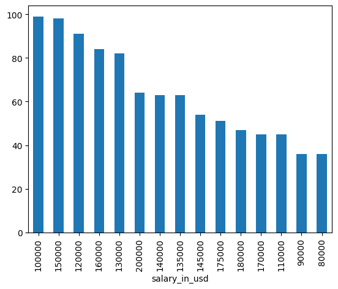

```python
# Ploting the top 15 most common salary amounts from the 'salary_in_usd' column in a bar chart and showing the plot.
Job = science_salaries ['salary_in_usd'].value_counts().head(15)
Job.plot(kind='bar')
mlp.show
```

2.Which job has the highest salaries? Illustrate with bar graph.

```
<function matplotlib.pyplot.show(close=None, block=None)>
```

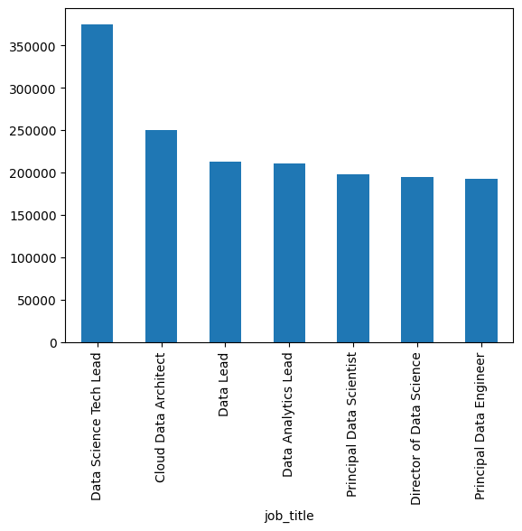

```python
# Ploting the average salary for the top 7 highest paying job titles from the science_salaries data frame and displaying the plot.
Highest_Salary = science_salaries.groupby('job_title').salary_in_usd.mean().sort_values(ascending=False).head(7)
Highest_Salary.plot(kind='bar')
mlp.show
```

3.Write a python program to find out salaries based on experience level. Illustrate it through bar graph.

```
<function matplotlib.pyplot.show(close=None, block=None)>
```

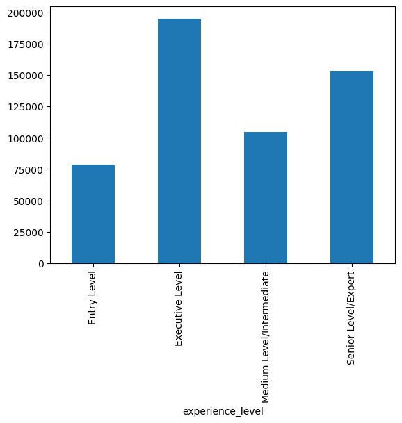

```python
# Ploting the average salary by experience level from the science_salaries data frame and displaying the plot.
SalariesExp = science_salaries.groupby('experience_level')['salary_in_usd'].mean()
SalariesExp.plot(kind='bar')
mlp.show
```

4.Write a Python program to show histogram and box plot of any chosen different variables. Use proper labels in the graph.

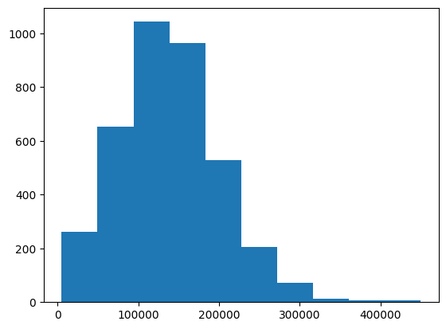

```python
# Ploting a histogram of the salary_in_usd column from the science_salaries data frame to visualize the distribution of salaries.
mlp.hist(science_salaries['salary_in_usd'])
```

[output not shown]

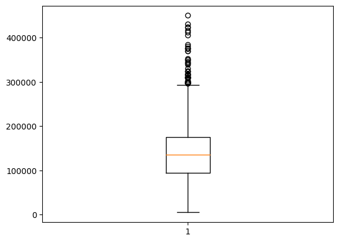

```python
# Creating a boxplot for the salary_in_usd column from the science_salaries data frame to visualize the distribution of salaries.
mlp.boxplot(science_salaries['salary_in_usd'])
```